# OLA Driver Churn Prediction

To predict whether a driver will be leaving the company or not based on their attributes like:

- Demographics (city, age, gender etc.)
- Tenure information (joining date, Last Date)
- Historical data regarding the performance of the driver (Quarterly rating, Monthly business acquired, grade, Income)

##### This is a binary classification problem.

# Importing Python Libraries

```python
import random
import pandas as pd
import numpy as np
import matplotlib.pyplot as plt
import seaborn as sns
from sklearn.preprocessing import MinMaxScaler, LabelEncoder, StandardScaler
from scipy.stats import shapiro, mannwhitneyu, chi2_contingency, boxcox
from sklearn.model_selection import train_test_split,GridSearchCV
from sklearn.ensemble import RandomForestClassifier, GradientBoostingClassifier
import warnings
warnings.filterwarnings("ignore")
from sklearn.model_selection import train_test_split
from sklearn.tree import DecisionTreeClassifier
from sklearn.impute import KNNImputer
from xgboost import XGBClassifier
import lightgbm as lgb
from lightgbm import LGBMClassifier
import math
import statsmodels.api as sm
from imblearn.over_sampling import SMOTE
from imblearn.pipeline import Pipeline
from sklearn.linear_model import LogisticRegression
from sklearn.svm import SVC
from sklearn.model_selection import StratifiedKFold, cross_validate, RandomizedSearchCV
from sklearn.metrics import (
    accuracy_score, precision_score, recall_score,
    f1_score, roc_auc_score, classification_report, confusion_matrix
)
import shap
```

# Loading the Data set and Preliminary Analysis

```python
df = pd.read_csv('ola_driver.csv')
```

```python
df.shape
```

```
(19104, 14)
```

```python
df.head(5)
```

|  | Unnamed: 0 | MMM-YY | Driver_ID | Age | Gender | City | Education_Level | Income | Dateofjoining | LastWorkingDate | Joining Designation | Grade | Total Business Value | Quarterly Rating |
| --- | --- | --- | --- | --- | --- | --- | --- | --- | --- | --- | --- | --- | --- | --- |
| 0 | 0 | 01/01/19 | 1 | 28.0 | 0.0 | C23 | 2 | 57387 | 24/12/18 | NaN | 1 | 1 | 2381060 | 2 |
| 1 | 1 | 02/01/19 | 1 | 28.0 | 0.0 | C23 | 2 | 57387 | 24/12/18 | NaN | 1 | 1 | -665480 | 2 |
| 2 | 2 | 03/01/19 | 1 | 28.0 | 0.0 | C23 | 2 | 57387 | 24/12/18 | 03/11/19 | 1 | 1 | 0 | 2 |
| 3 | 3 | 11/01/20 | 2 | 31.0 | 0.0 | C7 | 2 | 67016 | 11/06/20 | NaN | 2 | 2 | 0 | 1 |
| 4 | 4 | 12/01/20 | 2 | 31.0 | 0.0 | C7 | 2 | 67016 | 11/06/20 | NaN | 2 | 2 | 0 | 1 |

```python
df.info()
```

```
<class 'pandas.core.frame.DataFrame'>
RangeIndex: 19104 entries, 0 to 19103
Data columns (total 14 columns):
 #   Column                Non-Null Count  Dtype
---  ------                --------------  -----
 0   Unnamed: 0            19104 non-null  int64
 1   MMM-YY                19104 non-null  object
 2   Driver_ID             19104 non-null  int64
 3   Age                   19043 non-null  float64
 4   Gender                19052 non-null  float64
 5   City                  19104 non-null  object
 6   Education_Level       19104 non-null  int64
 7   Income                19104 non-null  int64
 8   Dateofjoining         19104 non-null  object
 9   LastWorkingDate       1616 non-null   object
 10  Joining Designation   19104 non-null  int64
 11  Grade                 19104 non-null  int64
 12  Total Business Value  19104 non-null  int64
 13  Quarterly Rating      19104 non-null  int64
dtypes: float64(2), int64(8), object(4)
memory usage: 2.0+ MB
```

```python
df.drop(columns='Unnamed: 0', inplace=True)
```

```python
# Converting to date time format
df['Reporting_date'] = pd.to_datetime(df['MMM-YY'], format='%d/%m/%y')
df['Dateofjoining'] = pd.to_datetime(df['Dateofjoining'], format='%d/%m/%y')
df['LastWorkingDate'] = pd.to_datetime(df['LastWorkingDate'], format='%d/%m/%y')
```

```python
df.drop(columns='MMM-YY', inplace=True)
```

```python
df.head(5)
```

|  | Driver_ID | Age | Gender | City | Education_Level | Income | Dateofjoining | LastWorkingDate | Joining Designation | Grade | Total Business Value | Quarterly Rating | Reporting_date |
| --- | --- | --- | --- | --- | --- | --- | --- | --- | --- | --- | --- | --- | --- |
| 0 | 1 | 28.0 | 0.0 | C23 | 2 | 57387 | 2018-12-24 | NaT | 1 | 1 | 2381060 | 2 | 2019-01-01 |
| 1 | 1 | 28.0 | 0.0 | C23 | 2 | 57387 | 2018-12-24 | NaT | 1 | 1 | -665480 | 2 | 2019-01-02 |
| 2 | 1 | 28.0 | 0.0 | C23 | 2 | 57387 | 2018-12-24 | 2019-11-03 | 1 | 1 | 0 | 2 | 2019-01-03 |
| 3 | 2 | 31.0 | 0.0 | C7 | 2 | 67016 | 2020-06-11 | NaT | 2 | 2 | 0 | 1 | 2020-01-11 |
| 4 | 2 | 31.0 | 0.0 | C7 | 2 | 67016 | 2020-06-11 | NaT | 2 | 2 | 0 | 1 | 2020-01-12 |

```python
df.describe()
```

|  | Driver_ID | Age | Gender | Education_Level | Income | Dateofjoining | LastWorkingDate | Joining Designation | Grade | Total Business Value | Quarterly Rating | Reporting_date |
| --- | --- | --- | --- | --- | --- | --- | --- | --- | --- | --- | --- | --- |
| count | 19104.000000 | 19043.000000 | 19052.000000 | 19104.000000 | 19104.000000 | 19104 | 1616 | 19104.000000 | 19104.000000 | 1.910400e+04 | 19104.000000 | 19104 |
| mean | 1415.591133 | 34.668435 | 0.418749 | 1.021671 | 65652.025126 | 2018-04-20 21:49:17.788944896 | 2019-12-26 23:22:34.455445760 | 1.690536 | 2.252670 | 5.716621e+05 | 2.008899 | 2019-07-04 22:36:06.331658240 |
| min | 1.000000 | 21.000000 | 0.000000 | 0.000000 | 10747.000000 | 2013-01-04 00:00:00 | 2018-12-31 00:00:00 | 1.000000 | 1.000000 | -6.000000e+06 | 1.000000 | 2019-01-01 00:00:00 |
| 25% | 710.000000 | 30.000000 | 0.000000 | 0.000000 | 42383.000000 | 2016-11-28 00:00:00 | 2019-06-10 00:00:00 | 1.000000 | 1.000000 | 0.000000e+00 | 1.000000 | 2019-01-06 00:00:00 |
| 50% | 1417.000000 | 34.000000 | 0.000000 | 1.000000 | 60087.000000 | 2018-09-19 00:00:00 | 2019-12-20 12:00:00 | 1.000000 | 2.000000 | 2.500000e+05 | 2.000000 | 2019-01-12 00:00:00 |
| 75% | 2137.000000 | 39.000000 | 1.000000 | 2.000000 | 83969.000000 | 2019-10-25 00:00:00 | 2020-07-14 00:00:00 | 2.000000 | 3.000000 | 6.997000e+05 | 3.000000 | 2020-01-07 00:00:00 |
| max | 2788.000000 | 58.000000 | 1.000000 | 2.000000 | 188418.000000 | 2020-12-28 00:00:00 | 2020-12-28 00:00:00 | 5.000000 | 5.000000 | 3.374772e+07 | 4.000000 | 2020-01-12 00:00:00 |
| std | 810.705321 | 6.257912 | 0.493367 | 0.800167 | 30914.515344 | NaN | NaN | 0.836984 | 1.026512 | 1.128312e+06 | 1.009832 | NaN |

```python
df.nunique()
```

```
Driver_ID                2381
Age                        36
Gender                      2
City                       29
Education_Level             3
Income                   2383
Dateofjoining             869
LastWorkingDate           493
Joining Designation         5
Grade                       5
Total Business Value    10181
Quarterly Rating            4
Reporting_date             24
dtype: int64
```

**👁️Observation**

- There are $2381$ drivers.

## Handling missing values

```python
# Percentage of null values
round(df.isna().sum()/len(df) * 100, 2)
```

```
Driver_ID                0.00
Age                      0.32
Gender                   0.27
City                     0.00
Education_Level          0.00
Income                   0.00
Dateofjoining            0.00
LastWorkingDate         91.54
Joining Designation      0.00
Grade                    0.00
Total Business Value     0.00
Quarterly Rating         0.00
Reporting_date           0.00
dtype: float64
```

### For 'Gender' column - we use 'Group-wise mode imputation'

```python
df['Gender'] = df.groupby('Driver_ID')['Gender'].transform(
    lambda x: x.fillna(x.mode()[0] if not x.mode().empty else x.mean()))
```

### For the 'Age' column - we use 'kNN imputation'

```python
df_num = df.select_dtypes(np.number)
df_num.head()
```

|  | Driver_ID | Age | Gender | Education_Level | Income | Joining Designation | Grade | Total Business Value | Quarterly Rating |
| --- | --- | --- | --- | --- | --- | --- | --- | --- | --- |
| 0 | 1 | 28.0 | 0.0 | 2 | 57387 | 1 | 1 | 2381060 | 2 |
| 1 | 1 | 28.0 | 0.0 | 2 | 57387 | 1 | 1 | -665480 | 2 |
| 2 | 1 | 28.0 | 0.0 | 2 | 57387 | 1 | 1 | 0 | 2 |
| 3 | 2 | 31.0 | 0.0 | 2 | 67016 | 2 | 2 | 0 | 1 |
| 4 | 2 | 31.0 | 0.0 | 2 | 67016 | 2 | 2 | 0 | 1 |

```python
imputer = KNNImputer(n_neighbors=5, weights='uniform', metric='nan_euclidean')
imputer.fit(df_num)
df_imp = imputer.transform(df_num)
df_imp = pd.DataFrame(df_imp)
df_imp.columns = df_num.columns
df_imp.head()
```

|  | Driver_ID | Age | Gender | Education_Level | Income | Joining Designation | Grade | Total Business Value | Quarterly Rating |
| --- | --- | --- | --- | --- | --- | --- | --- | --- | --- |
| 0 | 1.0 | 28.0 | 0.0 | 2.0 | 57387.0 | 1.0 | 1.0 | 2381060.0 | 2.0 |
| 1 | 1.0 | 28.0 | 0.0 | 2.0 | 57387.0 | 1.0 | 1.0 | -665480.0 | 2.0 |
| 2 | 1.0 | 28.0 | 0.0 | 2.0 | 57387.0 | 1.0 | 1.0 | 0.0 | 2.0 |
| 3 | 2.0 | 31.0 | 0.0 | 2.0 | 67016.0 | 2.0 | 2.0 | 0.0 | 1.0 |
| 4 | 2.0 | 31.0 | 0.0 | 2.0 | 67016.0 | 2.0 | 2.0 | 0.0 | 1.0 |

```python
rem_cols = list(set(df.columns).difference(set(df_imp.columns)))
rem_cols
```

```
['Dateofjoining', 'LastWorkingDate', 'City', 'Reporting_date']
```

```python
df_final = pd.concat([df_imp, df[rem_cols]], axis = 1)
df_final.head()
```

|  | Driver_ID | Age | Gender | Education_Level | Income | Joining Designation | Grade | Total Business Value | Quarterly Rating | Dateofjoining | LastWorkingDate | City | Reporting_date |
| --- | --- | --- | --- | --- | --- | --- | --- | --- | --- | --- | --- | --- | --- |
| 0 | 1.0 | 28.0 | 0.0 | 2.0 | 57387.0 | 1.0 | 1.0 | 2381060.0 | 2.0 | 2018-12-24 | NaT | C23 | 2019-01-01 |
| 1 | 1.0 | 28.0 | 0.0 | 2.0 | 57387.0 | 1.0 | 1.0 | -665480.0 | 2.0 | 2018-12-24 | NaT | C23 | 2019-01-02 |
| 2 | 1.0 | 28.0 | 0.0 | 2.0 | 57387.0 | 1.0 | 1.0 | 0.0 | 2.0 | 2018-12-24 | 2019-11-03 | C23 | 2019-01-03 |
| 3 | 2.0 | 31.0 | 0.0 | 2.0 | 67016.0 | 2.0 | 2.0 | 0.0 | 1.0 | 2020-06-11 | NaT | C7 | 2020-01-11 |
| 4 | 2.0 | 31.0 | 0.0 | 2.0 | 67016.0 | 2.0 | 2.0 | 0.0 | 1.0 | 2020-06-11 | NaT | C7 | 2020-01-12 |

```python
# Checking the concat is correct or not
df[df["Driver_ID"] == 43]
```

|  | Driver_ID | Age | Gender | City | Education_Level | Income | Dateofjoining | LastWorkingDate | Joining Designation | Grade | Total Business Value | Quarterly Rating | Reporting_date |
| --- | --- | --- | --- | --- | --- | --- | --- | --- | --- | --- | --- | --- | --- |
| 239 | 43 | 27.0 | 1.0 | C15 | 0 | 12906 | 2018-07-13 | NaT | 1 | 1 | 359890 | 1 | 2019-01-01 |
| 240 | 43 | 27.0 | 1.0 | C15 | 0 | 12906 | 2018-07-13 | 2019-02-20 | 1 | 1 | 0 | 1 | 2019-01-02 |

```python
df_final[df_final["Driver_ID"] == 43]
```

|  | Driver_ID | Age | Gender | Education_Level | Income | Joining Designation | Grade | Total Business Value | Quarterly Rating | Dateofjoining | LastWorkingDate | City | Reporting_date |
| --- | --- | --- | --- | --- | --- | --- | --- | --- | --- | --- | --- | --- | --- |
| 239 | 43.0 | 27.0 | 1.0 | 0.0 | 12906.0 | 1.0 | 1.0 | 359890.0 | 1.0 | 2018-07-13 | NaT | C15 | 2019-01-01 |
| 240 | 43.0 | 27.0 | 1.0 | 0.0 | 12906.0 | 1.0 | 1.0 | 0.0 | 1.0 | 2018-07-13 | 2019-02-20 | C15 | 2019-01-02 |

```python
round(df_final.isna().sum()/len(df_final)*100, 2)
```

```
Driver_ID                0.00
Age                      0.00
Gender                   0.00
Education_Level          0.00
Income                   0.00
Joining Designation      0.00
Grade                    0.00
Total Business Value     0.00
Quarterly Rating         0.00
Dateofjoining            0.00
LastWorkingDate         91.54
City                     0.00
Reporting_date           0.00
dtype: float64
```

## Grouping by driver ID

```python
function_dict = {'Age':'max', 'Gender':'first','City':'first',
                 'Education_Level':'last', 'Income':'last',
                 'Joining Designation':'last','Grade':'last',
                 'Dateofjoining':'last','LastWorkingDate':'last',
                 'Total Business Value':'sum','Quarterly Rating':'last'}
df_new=df_final.groupby(['Driver_ID','Reporting_date']).aggregate(function_dict)
df_new.reset_index(inplace =True)
df_new.head()
```

|  | Driver_ID | Reporting_date | Age | Gender | City | Education_Level | Income | Joining Designation | Grade | Dateofjoining | LastWorkingDate | Total Business Value | Quarterly Rating |
| --- | --- | --- | --- | --- | --- | --- | --- | --- | --- | --- | --- | --- | --- |
| 0 | 1.0 | 2019-01-01 | 28.0 | 0.0 | C23 | 2.0 | 57387.0 | 1.0 | 1.0 | 2018-12-24 | NaT | 2381060.0 | 2.0 |
| 1 | 1.0 | 2019-01-02 | 28.0 | 0.0 | C23 | 2.0 | 57387.0 | 1.0 | 1.0 | 2018-12-24 | NaT | -665480.0 | 2.0 |
| 2 | 1.0 | 2019-01-03 | 28.0 | 0.0 | C23 | 2.0 | 57387.0 | 1.0 | 1.0 | 2018-12-24 | 2019-11-03 | 0.0 | 2.0 |
| 3 | 2.0 | 2020-01-11 | 31.0 | 0.0 | C7 | 2.0 | 67016.0 | 2.0 | 2.0 | 2020-06-11 | NaT | 0.0 | 1.0 |
| 4 | 2.0 | 2020-01-12 | 31.0 | 0.0 | C7 | 2.0 | 67016.0 | 2.0 | 2.0 | 2020-06-11 | NaT | 0.0 | 1.0 |

```python
df_new[df_new["Driver_ID"] == 43]
```

|  | Driver_ID | Reporting_date | Age | Gender | City | Education_Level | Income | Joining Designation | Grade | Dateofjoining | LastWorkingDate | Total Business Value | Quarterly Rating |
| --- | --- | --- | --- | --- | --- | --- | --- | --- | --- | --- | --- | --- | --- |
| 239 | 43.0 | 2019-01-01 | 27.0 | 1.0 | C15 | 0.0 | 12906.0 | 1.0 | 1.0 | 2018-07-13 | NaT | 359890.0 | 1.0 |
| 240 | 43.0 | 2019-01-02 | 27.0 | 1.0 | C15 | 0.0 | 12906.0 | 1.0 | 1.0 | 2018-07-13 | 2019-02-20 | 0.0 | 1.0 |

```python
df1 = pd.DataFrame()
df1['Driver_ID']=df_final['Driver_ID'].unique()
```

### Aggregation at driver level

```python
#  Sort the DataFrame by 'Driver_ID' and 'Reporting date'
df_new_sorted = df_new.sort_values(['Driver_ID', 'Reporting_date'])

# Perform the aggregations
df1 = df_new_sorted.groupby('Driver_ID').agg({
    'Age': 'last',                      # Latest age per Driver_ID
    'Gender': 'first',                   # Latest gender per Driver_ID
    'City': 'last',                     # Latest city per Driver_ID
    'Education_Level': 'last',          # Latest education level per Driver_ID
    'Income': 'last',                   # Latest income per Driver_ID
    'Joining Designation': 'last',      # Latest joining designation per Driver_ID
    'Grade': 'last',                    # Latest grade per Driver_ID
    'Total Business Value': 'sum',      # Sum of business value per Driver_ID
    'Quarterly Rating': 'last'          # Latest quarterly rating per Driver_ID
}).reset_index()

df1.head()
```

|  | Driver_ID | Age | Gender | City | Education_Level | Income | Joining Designation | Grade | Total Business Value | Quarterly Rating |
| --- | --- | --- | --- | --- | --- | --- | --- | --- | --- | --- |
| 0 | 1.0 | 28.0 | 0.0 | C23 | 2.0 | 57387.0 | 1.0 | 1.0 | 1715580.0 | 2.0 |
| 1 | 2.0 | 31.0 | 0.0 | C7 | 2.0 | 67016.0 | 2.0 | 2.0 | 0.0 | 1.0 |
| 2 | 4.0 | 43.0 | 0.0 | C13 | 2.0 | 65603.0 | 2.0 | 2.0 | 350000.0 | 1.0 |
| 3 | 5.0 | 29.0 | 0.0 | C9 | 0.0 | 46368.0 | 1.0 | 1.0 | 120360.0 | 1.0 |
| 4 | 6.0 | 31.0 | 1.0 | C11 | 1.0 | 78728.0 | 3.0 | 3.0 | 1265000.0 | 2.0 |

```python
df1['Gender'].value_counts()
```

```
Gender
0.0    1404
1.0     977
Name: count, dtype: int64
```

### Creating a column which tells if the quarterly rating has increased for that employee for those whose quarterly rating has increased we assign the value 1

```python
df1 = df1.merge(
    df_final.groupby('Driver_ID')['Quarterly Rating']
      .agg(['first', 'last'])
      .assign(Quarterly_Rating_Increased=lambda x: (x['last'] > x['first']).astype(int))
      .reset_index()[['Driver_ID', 'Quarterly_Rating_Increased']],
    on='Driver_ID',
    how='left'
)
df1.head()
```

|  | Driver_ID | Age | Gender | City | Education_Level | Income | Joining Designation | Grade | Total Business Value | Quarterly Rating | Quarterly_Rating_Increased |
| --- | --- | --- | --- | --- | --- | --- | --- | --- | --- | --- | --- |
| 0 | 1.0 | 28.0 | 0.0 | C23 | 2.0 | 57387.0 | 1.0 | 1.0 | 1715580.0 | 2.0 | 0 |
| 1 | 2.0 | 31.0 | 0.0 | C7 | 2.0 | 67016.0 | 2.0 | 2.0 | 0.0 | 1.0 | 0 |
| 2 | 4.0 | 43.0 | 0.0 | C13 | 2.0 | 65603.0 | 2.0 | 2.0 | 350000.0 | 1.0 | 0 |
| 3 | 5.0 | 29.0 | 0.0 | C9 | 0.0 | 46368.0 | 1.0 | 1.0 | 120360.0 | 1.0 | 0 |
| 4 | 6.0 | 31.0 | 1.0 | C11 | 1.0 | 78728.0 | 3.0 | 3.0 | 1265000.0 | 2.0 | 1 |

## Feature engineering

### Creating the target column (if the driver left the company will have $1$ and driver still in the company will have $0$)

```python
# Determine if the last 'LastWorkingDate' is missing (NaN) for each Driver_ID
lwd = df_final.groupby('Driver_ID')['LastWorkingDate'].last().isna().reset_index()
lwd.rename(columns={'LastWorkingDate': 'target'}, inplace=True)
lwd['target'] = (~lwd['target']).astype(int)

lwd.head()
```

|  | Driver_ID | target |
| --- | --- | --- |
| 0 | 1.0 | 1 |
| 1 | 2.0 | 0 |
| 2 | 4.0 | 1 |
| 3 | 5.0 | 1 |
| 4 | 6.0 | 0 |

```python
# Merge this information back into df1
df1 = df1.merge(lwd, on='Driver_ID', how='left')
df1.head()
```

|  | Driver_ID | Age | Gender | City | Education_Level | Income | Joining Designation | Grade | Total Business Value | Quarterly Rating | Quarterly_Rating_Increased | target |
| --- | --- | --- | --- | --- | --- | --- | --- | --- | --- | --- | --- | --- |
| 0 | 1.0 | 28.0 | 0.0 | C23 | 2.0 | 57387.0 | 1.0 | 1.0 | 1715580.0 | 2.0 | 0 | 1 |
| 1 | 2.0 | 31.0 | 0.0 | C7 | 2.0 | 67016.0 | 2.0 | 2.0 | 0.0 | 1.0 | 0 | 0 |
| 2 | 4.0 | 43.0 | 0.0 | C13 | 2.0 | 65603.0 | 2.0 | 2.0 | 350000.0 | 1.0 | 0 | 1 |
| 3 | 5.0 | 29.0 | 0.0 | C9 | 0.0 | 46368.0 | 1.0 | 1.0 | 120360.0 | 1.0 | 0 | 1 |
| 4 | 6.0 | 31.0 | 1.0 | C11 | 1.0 | 78728.0 | 3.0 | 3.0 | 1265000.0 | 2.0 | 1 | 0 |

```python
df1['target'].value_counts()
```

```
target
1    1616
0     765
Name: count, dtype: int64
```

**👁️Observation**

- Out of $2381$ drivers, $1616$ drivers are already left the company and $765$ are still in the company.

### Creating a column which tells if the monthly income has increased for that employee for those whose monthly income has increased we assign the value 1

```python
inc_ch = df_final.groupby('Driver_ID')['Income'].agg(['first', 'last']).reset_index()
inc_ch['income_change'] = (inc_ch['first'] < inc_ch['last']).astype(int)
inc_ch.sample(5)
```

|  | Driver_ID | first | last | income_change |
| --- | --- | --- | --- | --- |
| 698 | 819.0 | 114358.0 | 114358.0 | 0 |
| 507 | 588.0 | 17660.0 | 17660.0 | 0 |
| 1503 | 1763.0 | 33042.0 | 33042.0 | 0 |
| 144 | 170.0 | 91458.0 | 91458.0 | 0 |
| 308 | 363.0 | 67650.0 | 67650.0 | 0 |

```python
df1 = df1.merge(inc_ch[['Driver_ID','income_change']], on='Driver_ID', how='left')
df1.sample(5)
```

|  | Driver_ID | Age | Gender | City | Education_Level | Income | Joining Designation | Grade | Total Business Value | Quarterly Rating | Quarterly_Rating_Increased | target | income_change |
| --- | --- | --- | --- | --- | --- | --- | --- | --- | --- | --- | --- | --- | --- |
| 1313 | 1544.0 | 37.0 | 0.0 | C13 | 1.0 | 90123.0 | 2.0 | 2.0 | 350000.0 | 1.0 | 0 | 1 | 0 |
| 1935 | 2270.0 | 34.0 | 1.0 | C9 | 2.0 | 78164.0 | 3.0 | 3.0 | 232140.0 | 1.0 | 0 | 1 | 0 |
| 460 | 537.0 | 35.0 | 1.0 | C29 | 1.0 | 84554.0 | 2.0 | 3.0 | 23376420.0 | 4.0 | 1 | 0 | 1 |
| 1854 | 2179.0 | 32.0 | 1.0 | C22 | 1.0 | 59105.0 | 1.0 | 2.0 | 18036100.0 | 3.0 | 0 | 0 | 0 |
| 1224 | 1439.0 | 31.0 | 1.0 | C7 | 1.0 | 49664.0 | 1.0 | 1.0 | 463890.0 | 1.0 | 0 | 1 | 0 |

### Statistical summary of the derived data

```python
df1.describe()
```

|  | Driver_ID | Age | Gender | Education_Level | Income | Joining Designation | Grade | Total Business Value | Quarterly Rating | Quarterly_Rating_Increased | target | income_change |
| --- | --- | --- | --- | --- | --- | --- | --- | --- | --- | --- | --- | --- |
| count | 2381.000000 | 2381.000000 | 2381.000000 | 2381.00000 | 2381.000000 | 2381.000000 | 2381.000000 | 2.381000e+03 | 2381.000000 | 2381.000000 | 2381.000000 | 2381.000000 |
| mean | 1397.559009 | 33.676018 | 0.410332 | 1.00756 | 59334.157077 | 1.820244 | 2.096598 | 4.586742e+06 | 1.427971 | 0.150357 | 0.678706 | 0.018060 |
| std | 806.161628 | 5.974057 | 0.491997 | 0.81629 | 28383.666384 | 0.841433 | 0.941522 | 9.127115e+06 | 0.809839 | 0.357496 | 0.467071 | 0.133195 |
| min | 1.000000 | 21.000000 | 0.000000 | 0.00000 | 10747.000000 | 1.000000 | 1.000000 | -1.385530e+06 | 1.000000 | 0.000000 | 0.000000 | 0.000000 |
| 25% | 695.000000 | 29.000000 | 0.000000 | 0.00000 | 39104.000000 | 1.000000 | 1.000000 | 0.000000e+00 | 1.000000 | 0.000000 | 0.000000 | 0.000000 |
| 50% | 1400.000000 | 33.000000 | 0.000000 | 1.00000 | 55315.000000 | 2.000000 | 2.000000 | 8.176800e+05 | 1.000000 | 0.000000 | 1.000000 | 0.000000 |
| 75% | 2100.000000 | 37.000000 | 1.000000 | 2.00000 | 75986.000000 | 2.000000 | 3.000000 | 4.173650e+06 | 2.000000 | 0.000000 | 1.000000 | 0.000000 |
| max | 2788.000000 | 58.000000 | 1.000000 | 2.00000 | 188418.000000 | 5.000000 | 5.000000 | 9.533106e+07 | 4.000000 | 1.000000 | 1.000000 | 1.000000 |

## Outlier treatment

```python
def outlier(data, col):
    q1 = data[col].quantile(0.25)
    q3 = data[col].quantile(0.75)
    iqr = q3 - q1

    lower_bound = q1 - 1.5 * iqr
    upper_bound = q3 + 1.5 * iqr

    # boolean mask for outliers
    mask = (data[col] < lower_bound) | (data[col] > upper_bound)

    # extract ONLY the outlier values
    outlier_vals = data.loc[mask, col]

    print(f"Outliers count for {col}: {mask.sum()}")
    print(f"\nOutlier values for {col}:\n{list(outlier_vals)}\n")

    return outlier_vals
```

```python
num_cols = df1.select_dtypes(include=['float', 'int']).columns.tolist()
num_cols
```

```
['Driver_ID',
 'Age',
 'Gender',
 'Education_Level',
 'Income',
 'Joining Designation',
 'Grade',
 'Total Business Value',
 'Quarterly Rating',
 'Quarterly_Rating_Increased',
 'target',
 'income_change']
```

```python
num_cols = ['Age', 'Income', 'Total Business Value']

for col in num_cols:
    outlier(df1, col)
```

```
Outliers count for Age: 25

Outlier values for Age:
[52.0, 51.0, 50.0, 51.0, 53.0, 52.0, 52.0, 54.0, 50.0, 51.0, 50.0, 50.0, 52.0, 52.0, 51.0, 52.0, 51.0, 55.0, 50.0, 52.0, 52.0, 58.0, 55.0, 53.0, 51.0]

Outliers count for Income: 48

Outlier values for Income:
[132577.0, 131347.0, 144978.0, 148588.0, 139139.0, 134529.0, 188418.0, 133752.0, 140769.0, 135879.0, 137082.0, 133783.0, 132558.0, 152234.0, 149403.0, 135436.0, 134302.0, 135414.0, 138069.0, 153109.0, 133978.0, 145861.0, 157124.0, 135337.0, 149637.0, 149354.0, 145483.0, 136307.0, 140833.0, 132819.0,…

Outliers count for Total Business Value: 336

Outlier values for Total Business Value:
[36351110.0, 69867900.0, 21755910.0, 33823290.0, 11723470.0, 22791310.0, 49225520.0, 12293120.0, 11718580.0, 12543500.0, 27309820.0, 17959920.0, 43531510.0, 36029220.0, 21415440.0, 13121470.0, 12674940.0, 40152720.0, 13939940.0, 24273480.0, 12087570.0, 19866290.0, 10666090.0, 31533700.0, 12182590.0,…
```

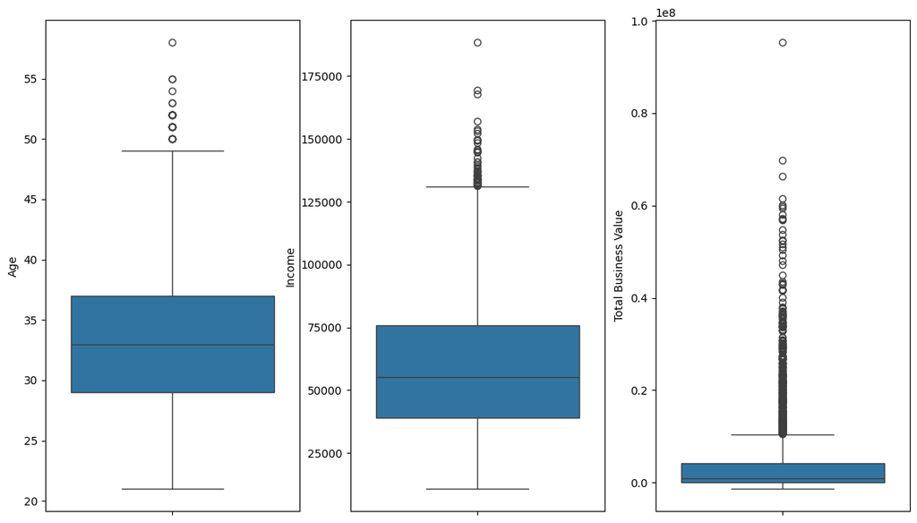

```python
plt.figure(figsize=(14, 8))

plt.subplot(1, 3, 1)
sns.boxplot(data=df1, y='Age')
plt.subplot(1, 3, 2)
sns.boxplot(data=df1, y='Income')
plt.subplot(1, 3, 3)
sns.boxplot(data=df1, y='Total Business Value')

plt.show()
```